# Speed-Acc-Child Noise first shift analysis

## Set up

read in personal library of helper functions

```r
source("../../helper_functions/libraries_and_functions.R")
theme_set(ggthemes::theme_few())
```

## Load data

```r
d <- read_csv("../../../data/3_final_merged_data/first_shifts/speed_acc_child_noise_fstshift_tidy.csv")
```

## Check the data

How many participants in the dataset?

```r
d %>% distinct(subid_short) %>% count() %>% kable()
```

| n |
| --- |
| 50 |

How many trials do we have for each participant?

```r
d %>%
  select(subid_short, tr.num) %>%
  unique() %>%
  group_by(subid_short) %>%
  count() %>%
  kable()
```

[output not shown]

How many trials does each participoant have in each condition?

```r
trials_df <- d %>%
  filter(!(is.na(rt))) %>%
  select(subid_short, tr.num, noise_condition) %>%
  unique() %>%
  group_by(subid_short, noise_condition) %>%
  count()

# add this information to the rest of the data
d %<>% left_join(., trials_df, by = c("subid_short", "noise_condition"))

trials_df %>% kable()
```

[output not shown]

What’s the average number of trials for each condition?

```r
d %>%
  filter(!(is.na(rt))) %>%
  select(subid_short, noise_condition, tr.num) %>%
  unique() %>%
  group_by(subid_short, noise_condition) %>%
  summarise(n = n()) %>%
  group_by(noise_condition) %>%
  summarise(avg_trials = mean(n) %>% round(digits = 2))
```

```
## # A tibble: 2 x 2
##   noise_condition avg_trials
##             <chr>      <dbl>
## 1           clear      14.19
## 2           noise      13.72
```

Let’s visualize it just to be sure there’s no difference in attrition.

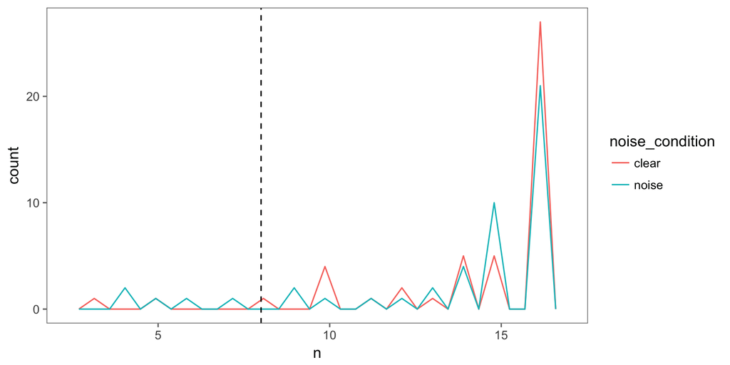

```r
d %>%
  filter(!(is.na(rt))) %>%
  select(subid_short, noise_condition, tr.num) %>%
  unique() %>%
  group_by(subid_short, noise_condition) %>%
  summarise(n = n()) %>%
  ggplot(aes(x = n, color = noise_condition)) +
  geom_freqpoly() +
  geom_vline(xintercept = 8, linetype = "dashed")
```

The distribution of trials completed looks pretty similar across conditions, which is nice.

## Data filtering

Remove shifts that do not start at center, participant exclusions, and extreme RTs

```r
d.analysis <- d %>%
  filter(!(is.na(shift_accuracy_clean)),
         response_onset_type == "noun",
         keep_et == "include",
         keep_runsheet == "keep",
         rt <= 1.5)
```

## Explore data via visualization

What does the distribution of age in the sample look like?

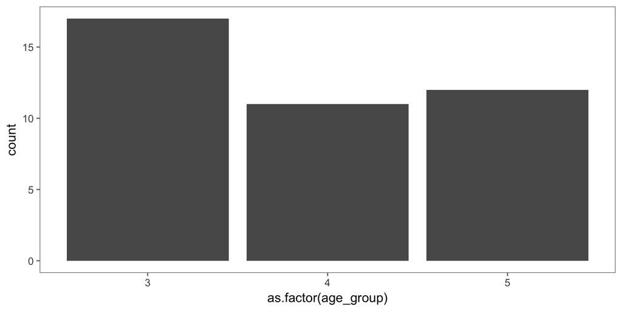

```r
d.analysis %>%
  select(subid_short, age_group) %>%
  unique() %>%
  ggplot(aes(x = as.factor(age_group))) +
  geom_histogram(stat = 'count')
```

Plot the distribution of Reaction Times (RT)

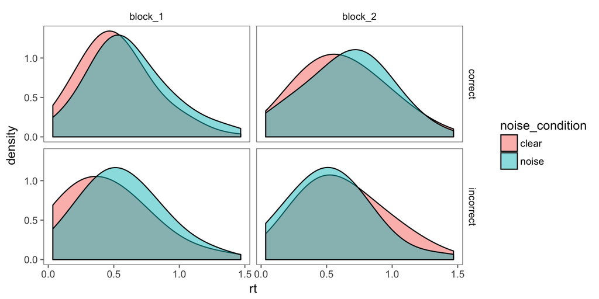

```r
d.analysis %>%
  filter(shift_start_location == "center") %>%
  ggplot() +
  geom_density(mapping = aes(x = rt, fill = noise_condition),
               alpha = 0.5, binwidth = 0.05, position = "identity",
               adjust = 2) +
  facet_grid(shift_accuracy_clean~block)
```

## Aggregated visualizations

Aggregate RT

```r
ss.rt <- d.analysis %>%
  filter(shift_start_location == "center") %>%
  group_by(subid_short, noise_condition, shift_accuracy_clean, block) %>%
  summarise(m_rt = median(rt, na.rm = T))
```

Make RT boxplot.

```r
rt_boxplot <- ss.rt %>%
  filter(block == "block_1") %>%
  ggplot(aes(x = noise_condition, y = m_rt)) +
  geom_boxplot(width = 0.2, fill = "darkorange") +
  ylim(0,1) +
  labs(x = "Condition", y = "RT (sec)")
```

Make plot for RT block effects

```r
rt_block <- ss.rt %>%
  ggplot(aes(x = noise_condition, y = m_rt, fill = shift_accuracy_clean)) +
  geom_boxplot(width = 0.3) +
  ylim(0,1) +
  labs(x = "Condition", y = "RT (sec)")  +
  facet_wrap(~block) +
  langcog::scale_fill_solarized() +
  theme(legend.position = "top")
```

Let’s try visualizing RT distributions using beeswarm plot to see if the shape of the RT distributions look different across the noise conditions.

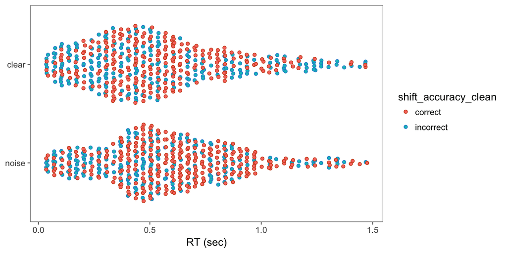

```r
d.analysis %>%
  ggplot(aes(x = forcats::fct_rev(noise_condition), y = rt,
             color = shift_accuracy_clean, fill = shift_accuracy_clean)) +
  ggbeeswarm::geom_quasirandom(shape = 21) +
  labs(y = "RT (sec)", x = NULL) +
  theme(legend.position = "right") +
  coord_flip() +
  langcog::scale_color_solarized()
```

### Aggregate Accuracy

```r
ss.acc <- d.analysis %>%
  filter(shift_start_location == "center") %>%
  group_by(noise_condition, subid_short, shift_accuracy_clean, block) %>%
  summarise(n = n()) %>%
  group_by(subid_short, noise_condition) %>%
  mutate(total_trials = sum(n),
         prop = round(n / total_trials, 2))
```

Now make accuracy boxplot

```r
acc_boxplot <- ss.acc %>%
  filter(shift_accuracy_clean == "correct") %>%
  ggplot() +
  geom_boxplot(mapping = aes(x = noise_condition, y = prop),
               width = 0.2,
               fill = "dodgerblue") +
  scale_y_continuous(limits=c(0,1)) +
  geom_hline(yintercept = 0.5, linetype = "dashed") +
  labs(x = "Condition", y = "Prop. Correct")
```

```r
acc_block <- ss.acc %>%
  filter(shift_accuracy_clean == "correct") %>%
  ggplot() +
  geom_boxplot(mapping = aes(x = noise_condition, y = prop),
               width = 0.2,
               fill = "dodgerblue") +
  scale_y_continuous(limits=c(0,1)) +
  geom_hline(yintercept = 0.5, linetype = "dashed") +
  labs(x = "Condition", y = "Prop. Correct") +
  facet_wrap(~block)
```

### Plot Acc and RT together

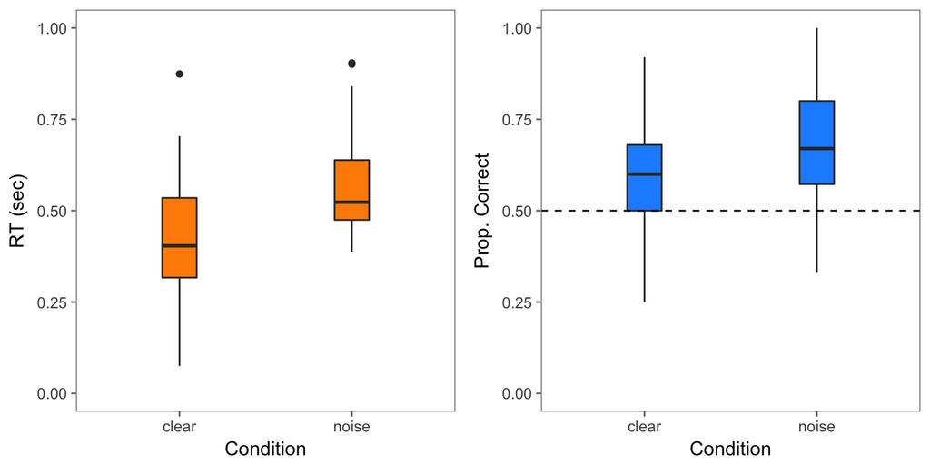

```r
cowplot::plot_grid(rt_boxplot, acc_boxplot)
```

### Plot Block effects

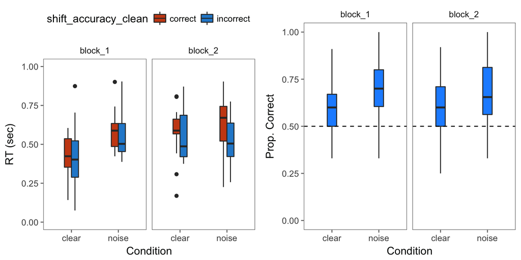

```r
cowplot::plot_grid(rt_block, acc_block)
```

## Learning effects

```r
n_trials_block <- 16
d.analysis %<>% mutate(tr.num.block = ifelse(block == "block_1",
                                             tr.num,
                                             tr.num - n_trials_block))
```

Summarise and plot the change in RT over the course of a block.

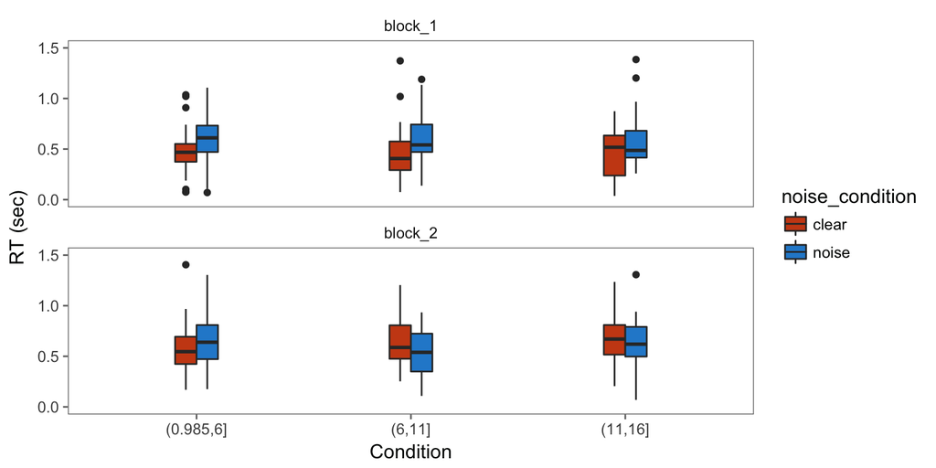

```r
d.analysis %>%
  filter(shift_start_location == "center") %>%
  mutate(tr.num.bin = cut(tr.num.block, breaks = 3)) %>%
  group_by(subid_short, noise_condition, shift_accuracy_clean, tr.num.bin, block) %>%
  summarise(m_rt = median(rt, na.rm = T))  %>%
  ggplot(aes(x = tr.num.bin, y = m_rt, fill = noise_condition)) +
  geom_boxplot(width = 0.2) +
  scale_y_continuous(limits=c(0,1.5)) +
  labs(x = "Condition", y = "RT (sec)") +
  facet_wrap(~block, ncol = 1) +
  langcog::scale_fill_solarized()
```

## Statistical models

```r
d.model <- d.analysis %>%
  filter(shift_start_location == "center") %>%
  mutate(correct = ifelse(shift_accuracy_clean == "correct", 1, 0))
```

Accuracy model

```r
m1.acc <- glmer(correct ~ noise_condition * block + (noise_condition|subid_short) + (1|target_image),
                data = d.model,
                family = "binomial")

summary(m1.acc)
```

```
## Generalized linear mixed model fit by maximum likelihood (Laplace
##   Approximation) [glmerMod]
##  Family: binomial  ( logit )
## Formula:
## correct ~ noise_condition * block + (noise_condition | subid_short) +
##     (1 | target_image)
##    Data: d.model
##
##      AIC      BIC   logLik deviance df.resid
##    883.5    919.5   -433.7    867.5      660
##
## Scaled residuals:
##     Min      1Q  Median      3Q     Max
## -1.7465 -1.2048  0.6597  0.7528  1.0355
##
## Random effects:
##  Groups       Name                 Variance Std.Dev. Corr
##  subid_short  (Intercept)          0.05189  0.2278
##               noise_conditionnoise 0.21201  0.4604   -1.00
##  target_image (Intercept)          0.06212  0.2492
## Number of obs: 668, groups:  subid_short, 40; target_image, 8
##
## Fixed effects:
##                                   Estimate Std. Error z value Pr(>|z|)
## (Intercept)                        0.38164    0.19824   1.925   0.0542 .
## noise_conditionnoise               0.40814    0.23489   1.738   0.0823 .
## blockblock_2                       0.07798    0.25194   0.310   0.7569
## noise_conditionnoise:blockblock_2 -0.26878    0.33594  -0.800   0.4237
## ---
## Signif. codes:  0 '***' 0.001 '**' 0.01 '*' 0.05 '.' 0.1 ' ' 1
##
## Correlation of Fixed Effects:
##             (Intr) ns_cnd blck_2
## nos_cndtnns -0.676
## blockblck_2 -0.631  0.486
## ns_cndtn:_2  0.426 -0.609 -0.683
```

RT model

```r
m1.rt  <- lmer(log(rt) ~ noise_condition * block + (noise_condition|subid_short) + (1|target_image),
               data = d.model)

summary(m1.rt)
```

```
## Linear mixed model fit by REML ['lmerMod']
## Formula:
## log(rt) ~ noise_condition * block + (noise_condition | subid_short) +
##     (1 | target_image)
##    Data: d.model
##
## REML criterion at convergence: 1346.4
##
## Scaled residuals:
##     Min      1Q  Median      3Q     Max
## -3.9258 -0.3402  0.1989  0.6486  2.0243
##
## Random effects:
##  Groups       Name                 Variance Std.Dev. Corr
##  subid_short  (Intercept)          0.059604 0.24414
##               noise_conditionnoise 0.043657 0.20894  -0.49
##  target_image (Intercept)          0.003451 0.05874
##  Residual                          0.396512 0.62969
## Number of obs: 668, groups:  subid_short, 40; target_image, 8
##
## Fixed effects:
##                                   Estimate Std. Error t value
## (Intercept)                       -0.94928    0.08099 -11.721
## noise_conditionnoise               0.27396    0.10155   2.698
## blockblock_2                       0.31884    0.10950   2.912
## noise_conditionnoise:blockblock_2 -0.34532    0.17330  -1.993
##
## Correlation of Fixed Effects:
##             (Intr) ns_cnd blck_2
## nos_cndtnns -0.745
## blockblck_2 -0.690  0.697
## ns_cndtn:_2  0.580 -0.792 -0.823
```